# Fish Biodiversity Patterns

Global Results

Hannah L. Owens

2026-08-25

# Readying the data

Read in data.

```r
fishData <- read.csv("data/iDigBioProcessedFishOccurrences_SingerAndOwens.csv")
```

# Mapping

## Simple point map

First, a regular point map of all records.

```
## Using x and y
##  as x and y coordinates, respectively.
```

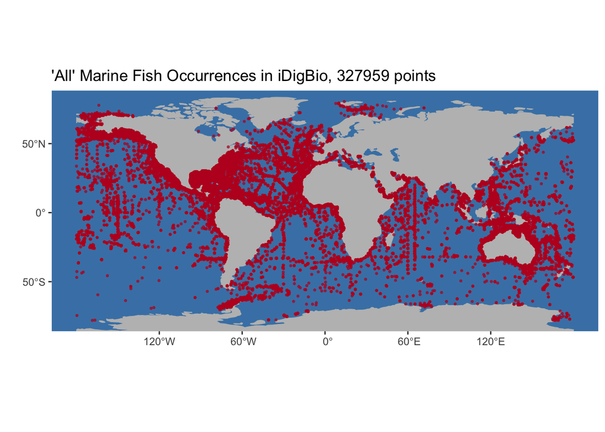

```r
fishHorizonComplete <- fishData |>
  select(iDigBio_dwc_decimalLongitude,
         iDigBio_dwc_decimalLatitude,
         SOcurated_depth, SOcurated_depthUncertainty,
         SOcurated_maximumDepthInMeters,
         WoRMS_scientificName,
         SOcurated_bibliographicCitation) |>
  drop_na(iDigBio_dwc_decimalLongitude,
         iDigBio_dwc_decimalLatitude,
         SOcurated_depth, SOcurated_depthUncertainty,
         SOcurated_maximumDepthInMeters,
         WoRMS_scientificName)

# Get rid of overland points
fishHorizonComplete <- vect(fishHorizonComplete,
                            geom = c("iDigBio_dwc_decimalLongitude",
                                     "iDigBio_dwc_decimalLatitude"))
crs(fishHorizonComplete) <- crs("EPSG:4326")
land <- vect(rnaturalearth::ne_countries(scale = "small",
                                         returnclass = "sf")[1])
land <- aggregate(land)
landFish <- is.related(fishHorizonComplete, land, "within")
fishHorizonComplete <- fishHorizonComplete[!landFish,]

pointMap(as.data.frame(geom(fishHorizonComplete)),
         spName = "'All' Marine Fish Occurrences in iDigBio",
         land = land)
```

```r
fishData <- fishHorizonComplete
```

## Sampling Density

First, we have to set things up by making a hexagon grid to aggregate the data. This was adapted and updated from https://strimas.com/post/hexagonal-grids/.

```r
# Set to Equal Earth projection
fishHorizonComplete <- project(fishHorizonComplete,
                               "EPSG:3857")
land <- project(land, crs(fishHorizonComplete))

# Study area
studyArea <- ext(fishHorizonComplete)
HexPols2 <- st_make_grid(studyArea , cellsize = 300000,
                         square = FALSE, crs = crs(land))

oceans <- vect(HexPols2)
crs(oceans) <- crs(land)
```

Now, how many records are in each cell?

```r
# Gridding it
point_density <- extract(x = oceans, y = fishHorizonComplete)
point_density <- table(point_density[,2])
counts <- NULL
for ( i in 1:length(oceans)){
  if (i %in% as.numeric(names(point_density))){
    counts <- c(counts, point_density[names(point_density) == i])
  } else{
    counts <- c(counts, NA)
  }
}

oceans$counts <- counts
oceans <- crop(oceans, ext(land))

my_breaks <- c(1, 10, 50, 100, 500, 1000, 5000, 6000)
my_col <- rgb(0, 0, 255, max = 255, alpha = 0, names = "clear")

pdf("Figures/GlobalSamplingDensity.pdf")
ggplot() +
  geom_spatvector(data = land, color = "gray50", alpha = .5) +
  geom_spatvector(data = oceans, aes(fill = counts), color = NA) +
  scale_fill_viridis_b(name = "Records", option = "A", na.value = my_col,
                       breaks = my_breaks, limits = c(0, max(my_breaks))) +
  theme_minimal() + coord_sf(crs = st_crs(4326), # WGS84 for more understandable mapping
                             xlim = c(-180, 180), expand = FALSE,
                             label_axes = list(bottom = "E", left = "N")) +
  ggtitle("Worldwide Sampling Density of Marine Bony Fishes, iDigBio") +
  scale_x_longitude(ticks = 40) + scale_y_latitude(ticks = 30)
dev.off()
```

## Depth Coverage

This map highlights regions of the ocean with differing depth coverage of sampling effort - specifically the percentage of “available depth” in each hexagon covered by records in iDigBio.

```r
# Get bathymetery
bathymetry <- rast("data/ETOPO_2022_v1_60s_N90W180_bed.tif")
bathymetry <- project(bathymetry, crs(oceans), method = "min")
oceans$bathymetry <- extract(x = bathymetry, y = oceans, fun = min)[,2]
oceans$bathymetry[oceans$bathymetry > 0] <- NA

# Get sampling depth
samplingDepth <- NULL
for (i in 1:length(oceans)){
  refs <- is.related(fishHorizonComplete, oceans[i], "within")
  if(any(refs)){
    maxDepth <- max(fishHorizonComplete[refs,"SOcurated_maximumDepthInMeters"], na.rm = TRUE)
  } else {
    maxDepth <- NA
  }
  samplingDepth <- c(samplingDepth, maxDepth)
}

oceans$maxSample <- -samplingDepth
oceans$samplingRatio <- oceans$maxSample/oceans$bathymetry
oceans$samplingRatio[oceans$samplingRatio > 1] <- 1

# Put it all together
pdf("Figures/GlobalSamplingRatio.pdf")
ggplot() +
  geom_spatvector(data = land, color = "gray50", alpha = .5) +
  geom_spatvector(data = oceans, aes(fill = samplingRatio), color = NA) +
  scale_fill_viridis_b(name = "Ratio", option = "A", na.value = my_col, breaks = seq(0,10, by =1)/10) +
  theme_minimal() + coord_sf(crs = st_crs(4326), xlim = c(-180, 180), expand = FALSE,
                             label_axes = list(bottom = "E", left = "N")) +
  ggtitle("Worldwide Depth Sampling Ratio of Marine Bony Fishes, iDigBio") +
  scale_x_longitude(ticks = 40) + scale_y_latitude(ticks = 30)
dev.off()
```

# Summary statistics

Finally, here are some sampling stats.

```
## [1] "There are 15871 cells in the global dataset."
```

```
## [1] "1519 cells in the global dataset have at least 10 records."
```

```
## [1] "509 cells in the global dataset have at least 100 records."
```

```
## [1] "11373 cells in the global dataset have bathymetry at or exceeding 200m."
```

```
## [1] "2087 have bathymetry at or exceeding 200m AND have at least one record from at or below 200m."
```

```
## [1] "There are 33 cells in the dataset that are sampled to at least 95% depth."
```

```
## [1] "There are 1 cells in the dataset that are sampled to full depth."
```

# Appendix: Additional analyses

The following analyses were also initially performed, but given the extreme spatial bias in sampling, we determined they were not fit for inclusion in the final manuscript. We include them here should they prove useful to curious readers.

## Data prep

First, we do some additional filtering to fit the data for our use, including removing records with excessive (i.e. 100m) uncertainty in depth.

```r
# Remove records with excessive uncertainty
print(paste0("Before removing records with a depth uncertainty of 100m or more, there are ", nrow(fishData), " records."))
```

```
## [1] "Before removing records with a depth uncertainty of 100m or more, there are 327959 records."
```

```r
fishData <- fishData[fishData$SOcurated_depthUncertainty < 100,]
print(paste0("After removing records with a depth uncertainty of 100m or more, there are ", nrow(fishData), " records."))
```

```
## [1] "After removing records with a depth uncertainty of 100m or more, there are 254699 records."
```

```r
fishData <- fishData[str_detect(fishData$WoRMS_scientificName, " sp\\.", negate = TRUE),]
fishData <- fishData[str_detect(fishData$WoRMS_scientificName, "species", negate = TRUE),]
print(paste0("After removing records that were not identified to species, there are ", nrow(fishData), " records."))
```

```
## [1] "After removing records that were not identified to species, there are 254699 records."
```

```r
# Zero empty bins
breakNumber <- 60 # Starts with 60 breaks, which is probably way too many
test <- TRUE
while (test){
    breakNumber <- breakNumber - 1
    tmp <- hist(fishData$SOcurated_depth,  breaks = breakNumber, plot = F)
    test <- 0 %in% tmp$counts # Checks if there are empty bins
}
zeroEmpty <- length(tmp$breaks)

# Minimum five per bin
breakNumber <- 60 # Starts with 60 breaks, which is probably way too many
test <- TRUE
while (test){
    breakNumber <- breakNumber - 1
    tmp <- hist(fishData$SOcurated_depth,  breaks = breakNumber, plot = F)
    test <- 5 >= min(tmp$counts) # Checks to see if any bins are less than five
}
fivePerBin <- length(tmp$breaks)

paste0("Number of bins if no bin can be empty: ",
       zeroEmpty)
```

```
## [1] "Number of bins if no bin can be empty: 17"
```

```r
paste0("Number of bins if each bin must have at least five observations: ",
       fivePerBin)
```

```
## [1] "Number of bins if each bin must have at least five observations: 5"
```

```r
rm(tmp, breakNumber, test)
```

## Calculate diversity statistics

Next, we define a function to calculate diversity statistics we need for downstream analysis.

```r
fishData <- data.frame(fishData) |>
  filter(grepl('\\s', WoRMS_scientificName)) |> # Remove entries not ID'ed to species
  drop_na(WoRMS_scientificName)

diversityStats <- function(x, binNumber){
  # Get breaks based on equal width bins
  breaks <- seq(min(x$SOcurated_depth),
              max(x$SOcurated_depth),
              (max(x$SOcurated_depth) - min(x$SOcurated_depth))/(binNumber))

  # Species richness per bin
  depthDiversityCount <- NULL
  effort <- NULL
  for(i in 2:length(breaks)){
    temp <- x %>% filter(SOcurated_depth >= breaks[i-1], breaks[i] >= SOcurated_depth)
    depthDiversityCount <- c(depthDiversityCount,
                             length(unique(temp$WoRMS_scientificName)))
    effort <- c(effort, nrow(temp))
  }
  x$SOcurated_depthBin <- cut(x$SOcurated_depth, breaks=breaks,
                    labels = paste0(round(breaks[-(binNumber+1)], digits = 0), " to ",
                                    round(breaks[-1], digits = 0)))

  # Put together all the useful outputs
  out <- list("breaks" = breaks, "depthDiversityCount" = depthDiversityCount, "effort" = effort,
              "data" = x, "binNumber" = binNumber)
  return(out)
}

# Do the calculations
zeroEmpty <- diversityStats(x = fishData, binNumber = zeroEmpty)
fivePerBin <- diversityStats(x = fishData, binNumber = fivePerBin)
```

## Species richness vs depth

For each binning strategy, we initially plotted diversity at depth. We include lines at 200m and 1000m, which are commonly-used boundaries for epipelagic and mesopelagic zone boundaries, respectively.

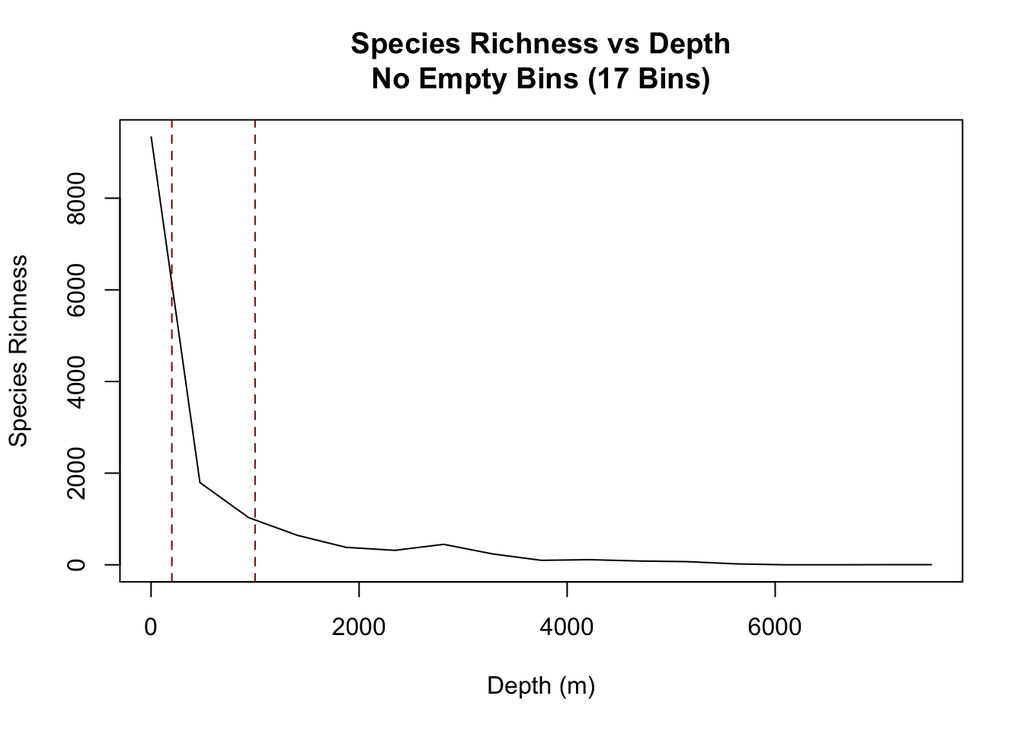

```r
# Plot diversity by depth
plot(cbind(zeroEmpty$breaks[-(length(zeroEmpty$breaks))], zeroEmpty$depthDiversityCount),
     type = "l", xlab = "Depth (m)", ylab = "Species Richness",
     main = paste0("Species Richness vs Depth\nNo Empty Bins (", zeroEmpty$binNumber, " Bins)"))
abline(v = 200, col = "darkred", lty = "dashed")
abline(v = 1000, col = "darkred", lty = "dashed")
```

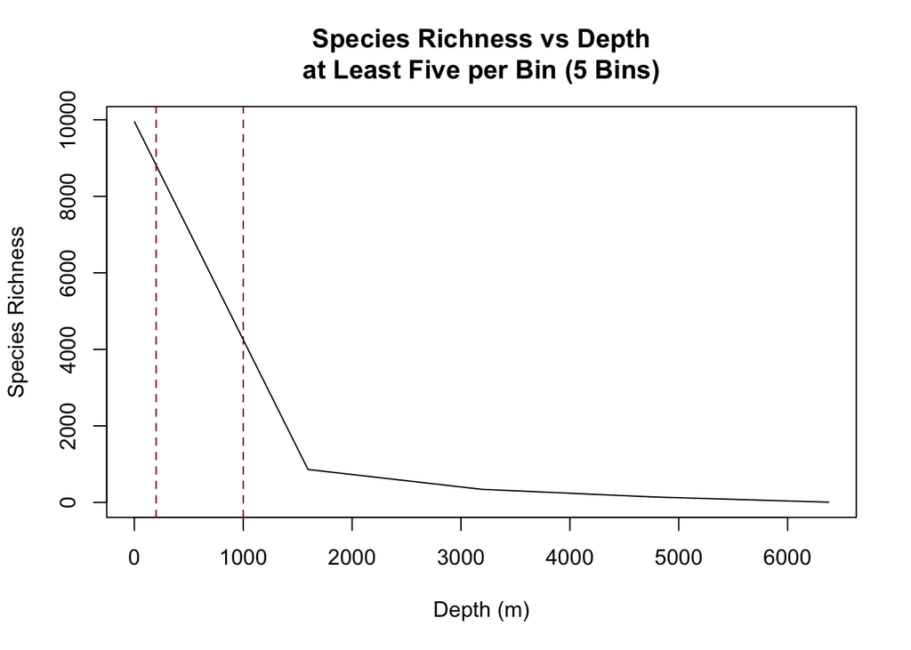

```r
plot(cbind(fivePerBin$breaks[-(length(fivePerBin$breaks))], fivePerBin$depthDiversityCount),
     type = "l", xlab = "Depth (m)", ylab = "Species Richness",
     main = paste0("Species Richness vs Depth\nat Least Five per Bin (", fivePerBin$binNumber, " Bins)"))
abline(v = 200, col = "darkred", lty = "dashed")
abline(v = 1000, col = "darkred", lty = "dashed")
```

## Null Model for Diversity

How does the observed distribution of diversity compare to a null distribution? That is, what if any observation was equally likely to be found in each depth bin–do we see the same distribution of diversity?

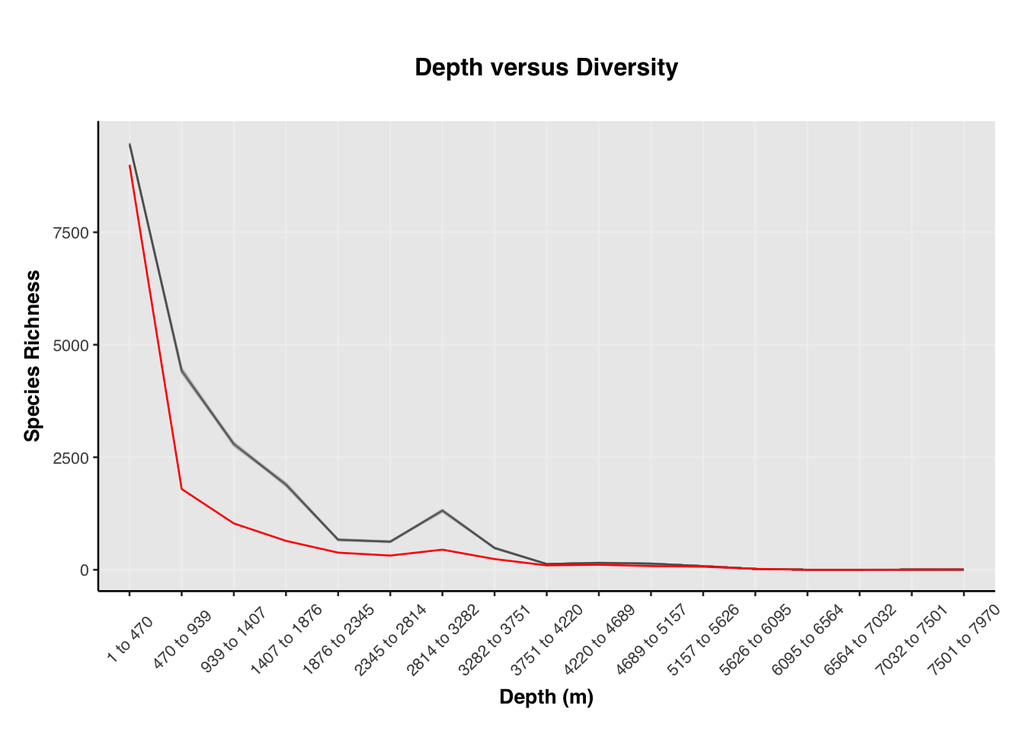

```r
calcEffortAndAlpha <-function(rawData){
  effortAndAlpha <- data.frame(table(rawData$data$SOcurated_depthBin))
  for(i in 1:nrow(effortAndAlpha)){
    binCommunity <- rawData$data[rawData$data$SOcurated_depthBin == effortAndAlpha$Var1[i],]
    binCommunity <- binCommunity[complete.cases(binCommunity$SOcurated_depthBin),]
    effortAndAlpha$alpha[i] <- length(unique(binCommunity$WoRMS_scientificName))
  }
  colnames(effortAndAlpha) <- c("Depth", "Count", "Species_Richness")
  return(effortAndAlpha)
}

effortAndAlpha <- calcEffortAndAlpha(rawData = zeroEmpty)

# Simulate data
fishDatSim <- zeroEmpty
fishDatSim$data <- fishDatSim$data[!is.na(fishDatSim$data$SOcurated_depthBin),]
fishDatSim <- lapply(1:100, FUN = function(x) {
    fishDatSim$data$SOcurated_depthBin <- sample(fishDatSim$data$SOcurated_depthBin)
    return(fishDatSim)
  })
# Calculate species richness
allDat <- lapply(fishDatSim, FUN = function(x) calcEffortAndAlpha(x))
# Plot sims and obs
P1 <- ggplot()
medProp <- c()
for(dat in allDat){
  P1 <- P1 +
    geom_line(data = dat, aes(x = Depth, y = Species_Richness, group = 1), alpha=0.01)
  medProp <- c(medProp, median(dat$prop))
}

finalPlot <- P1 +
  geom_line(data = effortAndAlpha, aes(x = Depth, y = Species_Richness, group = 1), col = "red") +
  theme_Publication() +
  labs( x = "Depth (m)", y = "Species Richness") +
  theme(axis.text.x = element_text(angle = 45, hjust=.5, vjust = .5)) +
  ggtitle("Depth versus Diversity")

finalPlot
```

```r
ggsave("Figures/DiversityObsVsSimWorld.png",finalPlot,height = 8.7, width = 11.4, units = "cm")
```

## Possible correlates with species richness

```r
effortAndAlpha$availableArea <- NA

bathymetry <- rast("data/ETOPO_2022_v1_60s_N90W180_bed.tif") %>%
  project(crs("epsg:4326"), method = "min")
```

```
## |---------|---------|---------|---------|=========================================
```

```r
cellBath <- cellSize(bathymetry, unit = "km")
```

```
## |---------|---------|---------|---------|=========================================
```

```r
for (i in 1:nrow(effortAndAlpha)){
  depths <- as.numeric(unlist(strsplit(as.character(effortAndAlpha$Depth[i]),
                                       " to ")))
  effortAndAlpha$availableArea[i] <- unlist(global(((bathymetry < -(depths[1])) * cellBath), sum, na.rm = T))
}
```

[output not shown]

It was suggested by Katherine Richardson, Owens’s colleague at the University of Copenhagen, that the bump in the diversity decay curve could be the result of thermoclines and/or pycnoclines. We used temperature and salinity data from the World Ocean Atlas 2018 dataset to investigate this idea, extracting mean temperature and salinity for each depth bin and comparing it to diversity. We also examined apparent oxygen utilization and nitrogen concentration as potential correlates, as these variables are also available via the WOA 2018 dataset and may be correlated with diversity.

```r
# Define extraction function
envDatExtract <- function(envRaster, mShp, breaks){
  # Get all the points
  dummyOccs <- data.frame(0, 0, 0)
  colnames(dummyOccs) <- c("longitude", "latitude", "depth")
  grid <- mSampling3D(occs = dummyOccs,
                      envBrick = envRaster,
                      mShp = mShp, verbose = F)
  allData <- cbind(grid,
                 xyzSample(grid, envBrick = envRaster, verbose = F))
  colnames(allData) <- c("longitude", "latitude", "depth", "Variable")

  # Assign points to bins and calculuate summary stats
  binSampledData <- NULL
  for(i in 2:length(breaks)){
    temp <- allData %>% filter(depth >= breaks[i-1], breaks[i] >= depth)
    binSampledData <- c(binSampledData, mean(temp[,4]))
  }
  return(binSampledData)
}

effortAndAlpha <- effortAndAlpha %>%
  rename("Available Area" = availableArea)

world <- vect(ext(c(-180,180,-90,90)))
crs(world) <- crs("epsg:4326")

effortAndAlpha$Temperature <-
  rast("~/Dropbox/DeepFishOccurrences/data/EnvironmentalData/ProcessedEnvtData/temperature.tif") %>%
  project(crs(world)) %>%
  crop(world, mask = TRUE) %>%
  envDatExtract(mShp = world, breaks = zeroEmpty$breaks)
effortAndAlpha$Salinity <- rast("~/Dropbox/DeepFishOccurrences/data/EnvironmentalData/ProcessedEnvtData/salinity.tif")  %>%
  project(crs(world)) %>%
  crop(world, mask = TRUE) %>%
  envDatExtract(mShp = world, breaks = zeroEmpty$breaks)
effortAndAlpha$AOU <- rast("~/Dropbox/DeepFishOccurrences/data/EnvironmentalData/ProcessedEnvtData/AOU.tif") %>%
  project(crs(world)) %>%
  crop(world, mask = TRUE) %>%
  envDatExtract(mShp = world, breaks = zeroEmpty$breaks)
effortAndAlpha$Nitrate <- rast("~/Dropbox/DeepFishOccurrences/data/EnvironmentalData/ProcessedEnvtData/nitrate.tif") %>%
  project(crs(world)) %>%
  crop(world, mask = TRUE) %>%
  envDatExtract(mShp = world, breaks = zeroEmpty$breaks)
```

Finally, we plotted the result.

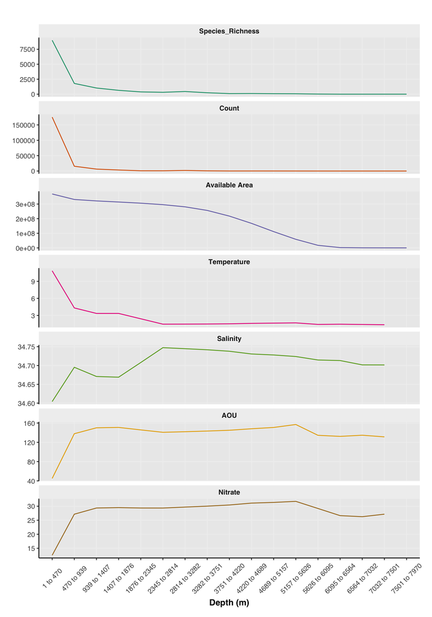

```r
effortAndAlphaLong <- reshape2::melt(effortAndAlpha[,c("Depth", "Species_Richness",
                                                        "Count", "Available Area",
                                                        "Temperature", "Salinity",
                                                        "AOU", "Nitrate")],
                                      id.vars = "Depth")

P1 <- ggplot(effortAndAlphaLong, aes(Depth, value,
                                      colour = variable, group = 1)) +
  geom_line() +
  theme_Publication() +
  labs( x = "Depth (m)") +
  theme(axis.text.x = element_text(angle = 45, hjust=.5, vjust = .5)) +
  scale_color_brewer(palette = "Dark2") +
  facet_wrap(variable~., ncol = 1, scales = "free_y") +
  theme(legend.position="none", axis.title.y = element_blank())
P1
```

```r
ggsave("Figures/WorldClines.png",P1,height = 12, width = 11.4, units = "cm")
```

# Bibliography of citations provided

```r
print(sort(unique(fishData$SOcurated_bibliographicCitation)))
```

```
##  [1] "Ayala-Duval E. 1998. Distribución espacio-temporal de las larvas de atunes en el Golfo de Tehuantepec, México. Unidad Iztapalapa. Universidad Autónoma Metropolitana. Bases de datos SNIB-CONABIO, proyecto G033. México, D. F."
##  [2] "De la Cruz-Agüero J. 2012. Registros ictiofaunísticos de localidades selectas de 10 regiones marinas prioritarias del Pacífico Mexicano. Centro Interdisciplinario de Ciencias Marinas. Instituto Politécnico Nacional. Bases de datos SNIB-CONABIO, proyectos EC013, DC028, BA005, V049, T028, K05…
##  [3] "Domínguez-Domínguez O. 2014. Listado taxonómico de la ictiofauna de la costa de Michoacán. Universidad Michoacana de San Nicolás de Hidalgo. Bases de datos SNIB-CONABIO proyecto No. HJ021 México, D.F."
##  [4] "Escobar-Briones E. G. 2006. Base de datos de fauna batial, abisopelágica y abisal del Golfo de México. Instituto de Ciencias del Mar y Limnología. Universidad Nacional Autónoma de México. Bases de datos SNIB-CONABIO, proyecto BE013. México, D. F."
##  [5] "Espinosa-Pérez H. 2002. Computarización de la Colección Nacional de Peces del Instituto de Biología UNAM. Colección CNPE. Instituto de Biología. Universidad Nacional Autónoma de México. Bases de datos SNIB-CONABIO, proyecto T023. México, D. F."
##  [6] "Flores-Coto C. 2002. Base de datos sobre ictioplancton para la Bahía de Campeche, México. Instituto de Ciencias del Mar y Limnología. Universidad Nacional Autónoma de México. Bases de datos SNIB-CONABIO, proyecto S109. México, D. F."
##  [7] "Franco-Gordo C. 2009. Base de datos y colección de distintos grupos del zooplancton de regiones marinas prioritarias de Jalisco y Colima en el Pacífico mexicano. Centro Universitario de la Costa Sur (CUCSUR). Universidad de Guadalajara. Bases de datos SNIB-CONABIO, proyecto EJ008. México, D…
##  [8] "http://ipt.vertnet.org:8080/ipt/resource.do?r=sio_marine_vertebrates."
##  [9] "Jiménez-Rosenberg S. P. A. y G. 2012. Actualización de la base de datos de diversidad taxonómica de las larvas de peces de Bahía Vizcaíno. Centro Interdisciplinario de Ciencias Marinas. Instituto Politécnico Nacional. Bases de datos SNIB-CONABIO, proyectos HA012, EC012 y S097. México, D. F.…
## [10] "NCSM [catalogNumber] - North Carolina Museum of Natural Sciences Ichthyology Collection"
## [11] "Sánchez-González S. 2000. Ictiofauna de la Bahía de Banderas Nayarit, Jalisco y zonas adyacentes, México. Instituto Nacional de la Pesca. Secretaría de Medio Ambiente, Recursos Naturales y Pesca (SEMARNAP). Bases de datos SNIB-CONABIO, proyecto L156. México, D. F."
## [12] "Sánchez-Velasco L. 2013. Inventario de larvas de peces en la región sur del Golfo de California (GAP 81, 85 y 86) y en el Pacífico Tropical Mexicano (GAP Centro Interdisciplinario de Ciencias Marinas. Instituto Politécnico Nacional. Bases de datos SNIB-CONABIO, proyecto HJ012. México, D. F.…
## [13] "Sanvicente-Añorve L. 1999. Biodiversidad y dinámica espacio-temporal del ictioplancton de dos sistemas lagunares de la Reserva de la Biósfera de Sian Ka'an. Unidad Zaragoza. Facultad de Estudios Superiores. Universidad Nacional Autónoma de México. Bases de datos SNIB-CONABIO, proyecto H078.…
## [14] "Soberón G., J. M. Nava, Z. V. Ojeda, L. A. Hurtado y O. Vidal. 1998. Consolidación y sistematización de las colecciones de referencia de peces y mamíferos marinos del ITESM Campus Guaymas. Unidad Guaymas. Instituto Tecnológico y de Estudios Superiores de Monterrey. Bases de datos SNIB-CONAB…
## [15] "Tapia-García M. 1997. Diversidad dinámica y patrones reproductivos en la comunidad de peces demersales del Golfo de Tehuantepec. Unidad Iztapalapa. Universidad Autónoma Metropolitana. Bases de datos SNIB-CONABIO, proyecto B094. México, D. F."
## [16] "University of Alabama Ichthyology Collection. http://ipt.vertnet.org:8080/ipt/resource.do?r=uaic_fish."
## [17] "urn:catalog:TCWC:Ichthyology. http://ipt.vertnet.org:8080/ipt/resource?r=tcwc_verts."
## [18] "Valdez-Moreno M. E., B. Prado y C. Pozo. 2017. Fortalecimiento de las colecciones de ECOSUR. Primera fase. El Colegio de la Frontera Sur. Bases de datos SNIB-CONABIO (colección de peces de Chetumal), proyectos ME006, HE009, EC001, S026 y B015. Ciudad de México"
## [19] "Vásquez-Yeomans, L. y J. J. 2005. Actualización de bases de datos de invertebrados (Rotifera, Cladocera y Copepoda) y peces. El Colegio de la Frontera Sur. Unidad Chetumal. Bases de datos PECES (Larvas). Proyectos No. AA011, S026_Ictioplancton, y H013. México, D.F."
## [20] "Vega-Cendejas M. E. 2005. Evaluación de la ictiofauna en las áreas focales del corredor biológico Unidad Mérida. Centro de Investigación y de Estudios Avanzados. Instituto Politécnico Nacional. Bases de datos SNIB-CONABIO, proyecto Y027. México, D. F."
## [21] "Vega-Cendejas M. E. 2007. Contribución a la riqueza ictiofaunística de la Reserva de Ría Lagartos, Yucatán. Unidad Mérida. Centro de Investigación y de Estudios Avanzados. Instituto Politécnico Nacional. Bases de datos SNIB-CONABIO, proyecto BK026. México, D. F."
## [22] "YPM ICH"
```